# Predicting Absenteeism - Group Assignment 1

## 1.7 Voting pattern of absentees

```python
employeeAbsenteeism_votes = pd.merge(absentees, votes, on='employee', how='left').fillna(0)
employeeAbsenteeism_votes.head()
```

|  | employee | companyAlias_x | from | to | reason | companyAlias_y | voteDate | vote |
| --- | --- | --- | --- | --- | --- | --- | --- | --- |
| 0 | 19Q | C1 | 10/1/18 0:10 | 10/26/18 0:10 | Workplace accident | C1 | 2017-06-13 02:06 | 3.0 |
| 1 | 19Q | C1 | 10/1/18 0:10 | 10/26/18 0:10 | Workplace accident | C1 | 2017-06-14 02:06 | 4.0 |
| 2 | 19Q | C1 | 10/1/18 0:10 | 10/26/18 0:10 | Workplace accident | C1 | 2017-06-15 02:06 | 3.0 |
| 3 | 19Q | C1 | 10/1/18 0:10 | 10/26/18 0:10 | Workplace accident | C1 | 2017-06-17 02:06 | 4.0 |
| 4 | 19Q | C1 | 10/1/18 0:10 | 10/26/18 0:10 | Workplace accident | C1 | 2017-06-20 02:06 | 3.0 |

```python
noAbsenteeVote = employeeAbsenteeism_votes[employeeAbsenteeism_votes.vote == 0]
noAbsenteeVote.head(30)
```

|  | employee | companyAlias_x | from | to | reason | companyAlias_y | voteDate | vote |
| --- | --- | --- | --- | --- | --- | --- | --- | --- |
| 8337 | zG | C1 | 10/1/18 0:10 | 10/31/18 0:10 | Common sickness or accident not related to th... | 0 | 0 | 0.0 |
| 8898 | gb3 | C1 | 10/29/18 0:10 | 10/31/18 0:10 | Common sickness or accident not related to th... | 0 | 0 | 0.0 |
| 8899 | xyG | C1 | 10/1/18 0:10 | 10/31/18 0:10 | Long term sick leave | 0 | 0 | 0.0 |
| 17158 | zG | C1 | 8/1/18 0:08 | 8/31/18 0:08 | Common sickness or accident not related to th... | 0 | 0 | 0.0 |
| 18003 | xyG | C1 | 8/1/18 0:08 | 8/31/18 0:08 | Long term sick leave | 0 | 0 | 0.0 |
| 27837 | xyG | C1 | 6/1/18 0:06 | 6/30/18 0:06 | Non job related sickness | 0 | 0 | 0.0 |

```python
print(f'{len(noAbsenteeVote.groupby(by="employee").count())} Employees who were absent did not vote')
```

```
3 Employees who were absent did not vote
```

```python
absenteeVote = employeeAbsenteeism_votes[employeeAbsenteeism_votes.vote > 0]
absenteeVote.head()
# employeeAbsenteeism_votes.groupby(by='employee').count()
```

|  | employee | companyAlias_x | from | to | reason | companyAlias_y | voteDate | vote |
| --- | --- | --- | --- | --- | --- | --- | --- | --- |
| 0 | 19Q | C1 | 10/1/18 0:10 | 10/26/18 0:10 | Workplace accident | C1 | 2017-06-13 02:06 | 3.0 |
| 1 | 19Q | C1 | 10/1/18 0:10 | 10/26/18 0:10 | Workplace accident | C1 | 2017-06-14 02:06 | 4.0 |
| 2 | 19Q | C1 | 10/1/18 0:10 | 10/26/18 0:10 | Workplace accident | C1 | 2017-06-15 02:06 | 3.0 |
| 3 | 19Q | C1 | 10/1/18 0:10 | 10/26/18 0:10 | Workplace accident | C1 | 2017-06-17 02:06 | 4.0 |
| 4 | 19Q | C1 | 10/1/18 0:10 | 10/26/18 0:10 | Workplace accident | C1 | 2017-06-20 02:06 | 3.0 |

```python
print(f'{len(absenteeVote.groupby(by="employee").count())} Employees who were absent did vote')
```

```
59 Employees who were absent did vote
```

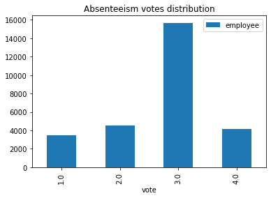

```python
absenteeVote.groupby(by='vote').count().reset_index().plot(kind='bar', x='vote', y='employee', title='Absenteeism votes distribution')
# absenteeVote.groupby(by='vote').count().reset_index()
```

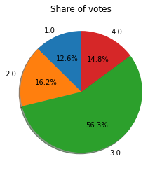

```python
pie_data = absenteeVote.groupby(by='vote').count().reset_index()
plt.pie(pie_data.employee, labels=pie_data.vote, autopct='%1.1f%%', shadow=True, startangle=90)
plt.title('Share of votes')
plt.show()
```

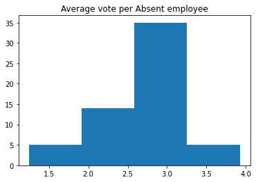

```python
avg_vote = absenteeVote.groupby(by='employee').mean().reset_index().vote
plt.hist(avg_vote, bins=4)
plt.title('Average vote per Absent employee')
plt.show()
```

## 1.8 Whether the employee still works at the company

The lastParticipationExists dataset shows the quitting date of employees who have already left the company. Of those who have already left the company, many of them left in 2018. This is significant, as employees who left the company before a given date should be removed from our training data, or else we will incorrectly identify them as "silent" employees who are in still in the company but simply do not vote, interact with or receive interactions from others.

[output not shown]

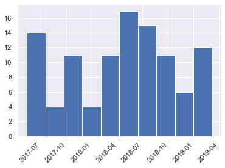

```python
quit['deletedOn'] = pd.to_datetime(quit['deletedOn'], format="%m/%d/%y %H:%M")

leftdf = quit[quit.stillExists == 0]

plt.hist(leftdf.deletedOn)
plt.xticks(rotation=45, ha='right')
```

# Part 2: Model construction and evaluation

## 2.1 Creating the input and output variables

Here are the input and output variables for the construction of the machine learning models.

Output variable: Whether an employee was absent for 5 days or more during the current 2-week period (i.e. first and second halves of June, August and October 2018)

Input variables relate to the 2-week period preceding each of the periods in the output variable

1. Likes and dislikes received
2. No. of comments made
3. Likes and dislikes given
4. Total number of votes
5. Average vote value (if no votes were cast, we consider it to be a neutral score of 2.5 on a 1-4 scale)
6. Number of “high” votes (a score of 3-4) and “low” votes (1-2)

We define a case of absenteeism as an employee who is absent for 5 days or more within a 2-week period. As such, an employee can be an absentee in one period and not be one in another period, depending on the number of days of absence during that period.

This definition of absenteeism may be ideal for this task for a few reasons:

1. There are many legitimate reasons for an employee to be absent which do not cause concern for the company, especially if he/she is only absent for several days within half a month. He/she may be genuinely ill, and require several days for recovery. Therefore, short absences are a common and even inevitable phenomenon that need not be reduced. However, if an employee is absent for more than 5 days in 2 weeks, the company should pay closer attention, as it may be a pattern of behaviour that significantly affects productivity if widespread among employees.
2. Cases of absenteeism in the dataset are fragmented as 3 distinct timeframes: June, August and October, which we further break in half. Suppose an employee is only absent for many days in the first half of June, and has not been absent since. First, we would be unfair and inaccurate to label this employee as an absentee permanently, since that behaviour was not consistent throughout June to October. Next, for the sake of prediction, it would make more sense to observe his/her behaviour immediately before that period, as possible relevant features to predict absenteeism in the current period. The worse alternative is averaging out the features and actions of an employee throughout all available time (2017-2019), which would render the prediction model imprecise.

```python
comments['commentDate'] = pd.to_datetime(comments['commentDate'], format="%Y-%m-%d %H:%M")
interactions['actionDate'] = pd.to_datetime(interactions['actionDate'], format="%Y-%m-%d %H:%M")
votes["voteDate"] = pd.to_datetime(votes["voteDate"], format="%Y-%m-%d %H:%M")
absentees['from'] = pd.to_datetime(absentees['from'], format="%m/%d/%y %H:%M")
absentees['to'] = pd.to_datetime(absentees['to'], format="%m/%d/%y %H:%M")
quit['deletedOn'] = pd.to_datetime(quit['deletedOn'], format="%m/%d/%y %H:%M")
```

We observe 6 two-week periods for our analysis of absentee cases, which are the first half and the second half of June, August and October 2018 respectively. These are the "current periods" of our output variable.  
For our input variables, we also observe 6 two-week periods, which are the two-week period immediately preceding each of the "current periods" in our output variables, i.e. second half of May, first half of June, second half of July, first half of August, second half of September and first half of October.

```python
start_date_out = [datetime(2018, 6, 1, 0, 0), datetime(2018, 6, 16, 0, 0),
              datetime(2018, 8, 1, 0, 0), datetime(2018, 8, 16, 0, 0),
              datetime(2018, 10, 1, 0, 0), datetime(2018, 10, 16, 0, 0)]

end_date_out = [datetime(2018, 6, 16, 0, 0), datetime(2018, 7, 1, 0, 0),
            datetime(2018, 8, 16, 0, 0), datetime(2018, 9, 1, 0, 0),
            datetime(2018, 10, 16, 0, 0), datetime(2018, 11, 1, 0, 0)]


start_date_in = [datetime(2018, 5, 16, 0, 0), datetime(2018, 6, 1, 0, 0),
              datetime(2018, 7, 16, 0, 0), datetime(2018, 8, 1, 0, 0),
              datetime(2018, 9, 16, 0, 0), datetime(2018, 10, 1, 0, 0)]

end_date_in = [datetime(2018, 6, 1, 0, 0), datetime(2018, 6, 16, 0, 0),
            datetime(2018, 8, 1, 0, 0), datetime(2018, 8, 16, 0, 0),
            datetime(2018, 10, 1, 0, 0), datetime(2018, 10, 16, 0, 0)]
```

```python
all_data = pd.DataFrame()

for i in range(len(start_date_in)):
    received = comments[(comments['commentDate'] >= start_date_in[i]) & (comments['commentDate'] <= end_date_in[i])]
    # Total dislikes received in comments made by the employee
    dis_received = received.groupby('employee')['dislikes'].sum()

    # Total likes received in comments made by the employee
    like_received = received.groupby('employee')['likes'].sum()

    # No. of comments made by the employee
    comment_count = received.groupby('employee')['commentId'].count()

    given = interactions[(interactions['actionDate'] >= start_date_in[i]) & (interactions['actionDate'] <= end_date_in[i])]

    # Total dislikes given by the employee
    dis_given = given.groupby('employee')['interaction'].apply(lambda x: (x == -1).sum())

    # Total likes given by the employee
    like_given = given.groupby('employee')['interaction'].apply(lambda x: (x == 1).sum())

    vote = votes[(votes['voteDate'] >= start_date_in[i]) & (votes['voteDate'] <= end_date_in[i])]

    # Average vote value of the employee
    avg_vote = vote.groupby('employee')['vote'].mean()
    avg_vote = avg_vote.rename('a')

    # No. of votes made by the employee
    vote_count = vote.groupby('employee')['vote'].count()
    vote_count = vote_count.rename('b')

    # No. of high-scoring votes (3 or 4)
    high_vote = vote.groupby('employee')['vote'].apply(lambda x: (x >= 3).sum())
    high_vote = high_vote.rename('c')

    # No. of low-scoring votes (1 or 2)
    low_vote = vote.groupby('employee')['vote'].apply(lambda x: (x <= 2).sum())
    low_vote = low_vote.rename('d')

    # List of employees who were absent during the current period
    absent = absentees[((absentees['from'] >= start_date_out[i]) & (absentees['from'] <= end_date_out[i]))|
                      ((absentees['to'] >= start_date_out[i]) & (absentees['to'] <= end_date_out[i]))]
    absent = absent.reset_index(drop=True)

    # Length of absence (if total days of absence during 2-week period >= 5, then count as absentee)
    len_list = []
    for k in range(len(absent)):
        if absent['from'][k] < start_date_out[i]:
            len_list.append(absent['to'][k] - start_date_out[i] + timedelta(days = 1))
        elif absent['to'][k] > end_date_out[i]:
            len_list.append(end_date_out[i] - absent['from'][k])
        else:
            len_list.append(absent['to'][k] - absent['from'][k] + timedelta(days = 1))

    absent['length'] = len_list

    dat = pd.DataFrame()
    dat = absent.groupby('employee')['length'].sum().to_frame()
    dat = dat.rename_axis('employee').reset_index()
    dat['length'] = [x.round(freq = 'D').days for x in dat['length']]

    alist = []
    for j in range(len(dat.length)):
        if dat.length[j] >= 5:
            alist.append(1)
        else:
            alist.append(0)
    dat['absent'] = alist


    quit_list = quit.employee[quit['deletedOn'] < start_date_out[i]].to_list()
    all_emp = quit['employee'].unique()
    cur_emp = pd.DataFrame()
    cur_emp['employee'] = [x for x in all_emp if x not in quit_list]

    dat = pd.merge(cur_emp, dat, on='employee', how='left').fillna(0)

    dat = pd.merge(dat, dis_received, on='employee', how='left').fillna(0)
    dat = pd.merge(dat, like_received, on='employee', how='left').fillna(0)
    dat = pd.merge(dat, comment_count, on='employee', how='left').fillna(0)
    dat = pd.merge(dat, dis_given, on='employee', how='left').fillna(0)
    dat = pd.merge(dat, like_given, on='employee', how='left').fillna(0)
    dat = pd.merge(dat, high_vote, on='employee', how='left').fillna(0)
    dat = pd.merge(dat, low_vote, on='employee', how='left').fillna(0)
    # If the employee did not vote during the period, the default average vote value a neutral score of 2.5.
    dat = pd.merge(dat, avg_vote, on='employee', how='left').fillna(2.5)
    dat = pd.merge(dat, vote_count, on='employee', how='left').fillna(0)

    # Period 0 = First half of June; Period 1 = Second half of June; Period 2 = First half of August...
    dat['period'] = i

    dat.columns = ['employee','length','absent','dis_received','like_received','comment_count','dis_given','like_given',
                  'high_vote','low_vote','avg_vote','vote_count','period']
    all_data = pd.concat([all_data,dat])
```

```python
all_data[all_data['absent']==1]
all_data['absent'].value_counts()
all_data.groupby('absent').mean()
```

| absent | length | dis_received | like_received | comment_count | dis_given | like_given | high_vote | low_vote | avg_vote | vote_count | period |
| --- | --- | --- | --- | --- | --- | --- | --- | --- | --- | --- | --- |
| 0.0 | 0.028326 | 1.243348 | 3.032618 | 0.193991 | 1.172103 | 2.966094 | 4.587124 | 1.874678 | 2.740827 | 6.461803 | 2.461803 |
| 1.0 | 13.778761 | 0.539823 | 2.628319 | 0.123894 | 1.681416 | 3.017699 | 4.831858 | 2.327434 | 2.701240 | 7.159292 | 2.389381 |

We can make a simple comparison of absentee cases (1) and non-absentee cases (0) by comparing the means of each input variable. On average, absentees receive less dislikes and likes from colleagues; they comment less frequently.  
Absentees give more dislikes and a similar number of likes, compared with their non-absent counterparts.  
Absentees' vote score is slightly lower than that of non-absentees, while voting more frequently.

## 2.2 Splitting the data into training-validation-test set and Oversampling

```python
X_train, X_val_test, y_train, y_val_test = train_test_split(all_data.iloc[:,3:12], all_data.iloc[:,2],
                                                    test_size=0.4, random_state=42)

X_valid, X_test, y_valid, y_test = train_test_split(X_val_test,y_val_test,test_size=0.5,random_state = 42)
X_train
y_train
```

```
152    0.0
132    0.0
212    0.0
190    1.0
288    0.0
      ...
391    0.0
255    0.0
290    0.0
47     0.0
20     0.0
Name: absent, Length: 1465, dtype: float64
```

There is a significant imbalance of test samples in our training set, as rows containing our interested class, i.e. absentees, are rare. They only make up 64 out of a total of 1465 samples, i.e. less than 5%. Therefore, we use oversampling method to ensure that our training dataset has an equal number of both classes.

```python
y_train.value_counts()
```

```
0.0    1401
1.0      64
Name: absent, dtype: int64
```

```python
ros = RandomOverSampler(random_state=42)
X_res, y_res = ros.fit_resample(X_train, y_train)

X_res = pd.DataFrame(data=X_res,columns=X_train.columns)
y_res= pd.DataFrame(data=y_res,columns=['absent'])
y_res.value_counts()
```

```
absent
0.0       1401
1.0       1401
dtype: int64
```

## 2.3 Decision tree

```
Index(['dis_received', 'like_received', 'comment_count', 'dis_given',
       'like_given', 'high_vote', 'low_vote', 'avg_vote', 'vote_count'],
      dtype='object')
```

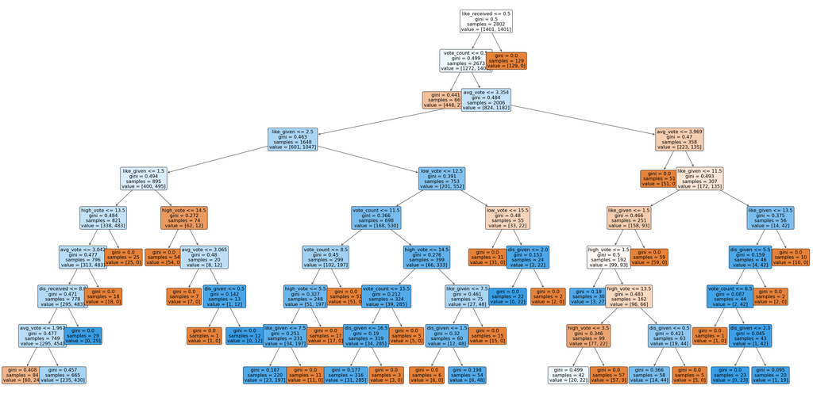

```python
clf = tree.DecisionTreeClassifier(criterion="gini",random_state=42, max_depth = 9)
clf = clf.fit(X_res, y_res)

plt.figure(figsize=(50,25))
tree.plot_tree(clf,
                   feature_names = all_data.iloc[:,3:12].columns,
                   rounded = True,
                   filled = True,
                   fontsize=16)
all_data.iloc[:,3:12].columns
```

We try different max depths for the tree. A tree using Gini index as the splitting criterion with max depth of 9 produces high accuracy and moderately high sensitivity score for the validation data.

|  | maxdepth | accuracy | sensitivity | average |
| --- | --- | --- | --- | --- |
| 0 | 1 | 0.116564 | 0.80 | 0.458282 |
| 1 | 2 | 0.429448 | 0.76 | 0.594724 |
| 2 | 3 | 0.556237 | 0.72 | 0.638119 |
| 3 | 4 | 0.556237 | 0.72 | 0.638119 |
| 4 | 5 | 0.627812 | 0.72 | 0.673906 |
| 5 | 6 | 0.642127 | 0.72 | 0.681063 |
| 6 | 7 | 0.687117 | 0.72 | 0.703558 |
| 7 | 8 | 0.705521 | 0.68 | 0.692761 |
| 8 | 9 | 0.758691 | 0.68 | 0.719346 |
| 9 | 10 | 0.775051 | 0.56 | 0.667526 |
| 10 | 11 | 0.793456 | 0.52 | 0.656728 |
| 11 | 12 | 0.793456 | 0.52 | 0.656728 |
| 12 | 13 | 0.805726 | 0.52 | 0.662863 |
| 13 | 14 | 0.805726 | 0.52 | 0.662863 |
| 14 | 15 | 0.807771 | 0.48 | 0.643885 |
| 15 | 16 | 0.807771 | 0.48 | 0.643885 |
| 16 | 17 | 0.809816 | 0.40 | 0.604908 |
| 17 | 18 | 0.809816 | 0.40 | 0.604908 |
| 18 | 19 | 0.836401 | 0.40 | 0.618200 |
| 19 | 20 | 0.832311 | 0.40 | 0.616155 |

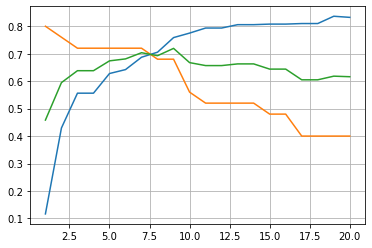

```python
results = []
for k in range(1,21):
    clfn = tree.DecisionTreeClassifier(criterion="gini", max_depth = k, random_state = 42,
                                       min_impurity_decrease = 0.001)
    clfn = clfn.fit(X_res, y_res)
    results.append({
        'maxdepth': k,
        'accuracy': accuracy_score(y_valid, clfn.predict(X_valid)),
        'sensitivity': recall_score(y_valid, clfn.predict(X_valid)),
        'average': (accuracy_score(y_valid, clfn.predict(X_valid))+recall_score(y_valid, clfn.predict(X_valid)))/2
    })

results = pd.DataFrame(results)

plt.plot(results.maxdepth, results.accuracy)
plt.plot(results.maxdepth, results.sensitivity)
plt.plot(results.maxdepth, results.average)
plt.grid()
results
```

```python
# Confusion matrix of validation set in Gini decision tree with max depth = 9
confusion_matrix(y_valid, clf.predict(X_valid))
```

```
array([[355, 109],
       [  8,  17]])
```

```python
clfn = tree.DecisionTreeClassifier(criterion="gini", max_depth = 9, random_state = 42)
clfn = clfn.fit(X_res, y_res)
print('Test set accuracy score:',accuracy_score(y_test, clfn.predict(X_test)))
print('Test set sensitivity score:',recall_score(y_test, clfn.predict(X_test)))
```

```
Test set accuracy score: 0.7300613496932515
Test set sensitivity score: 0.5416666666666666
```

```python
# Confusion matrix of test set in Gini decision tree with max depth = 9
confusion_matrix(y_test, clfn.predict(X_test))
```

```
array([[344, 121],
       [ 11,  13]])
```

We calculated the feature importances in our chosen decision tree. 5 features have a feature importance of more than 0.1: number of votes, number of likes given, number of high votes, average vote value, and number of likes received. These features can be considered as important predictors of absenteeism. Keeping track of them can help the company identify employees with a high risk of being absent for 5 or more days in the next 2 week period.

```
<BarContainer object of 9 artists>
```

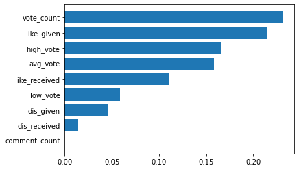

```python
impdf = pd.DataFrame({"feature":all_data.iloc[:,3:12].columns,
                      "importance":clf.feature_importances_})

impdf = impdf.sort_values('importance')

plt.barh(impdf.feature, impdf.importance)
```

## 2.4 Support vector machine

We normalise the training data before training the support vector machine.

```python
scaler = StandardScaler()
X_res_norm = scaler.fit_transform(X_res)
X_valid_norm = scaler.transform(X_valid)
X_test_norm = scaler.transform(X_test)
```

Comparing RBF and linear kernel, we find that the RBF kernel gives the best performance. When applied with validation data, an SVM model with RBF kernel has much better performance, especially in terms of sensitivity score, than a model with a linear kernel.

```python
results_svm = []
kernel_list = ['linear','rbf']
for k in kernel_list:
    svm_clf = svm.SVC(kernel = k)
    svm_clf.fit(X_res_norm,y_res.values.ravel())
    results_svm.append({
        'kernel': k,
        'accuracy': accuracy_score(y_valid, svm_clf.predict(X_valid_norm)),
        'sensitivity': recall_score(y_valid, svm_clf.predict(X_valid_norm)),
    })

results_svm = pd.DataFrame(results_svm)
results_svm
```

|  | kernel | accuracy | sensitivity |
| --- | --- | --- | --- |
| 0 | linear | 0.615542 | 0.12 |
| 1 | rbf | 0.597137 | 0.60 |

When applied with test data, the RBF-SVM model has an accuracy score of 58% and sensitivity score of 71%. It has an even higher sensitivity score than our best-performing decision tree, but at the expense of accuracy.

```python
svm_clfn = svm.SVC(kernel = 'rbf').fit(X_res_norm,y_res.values.ravel())

print('Test set accuracy score:',accuracy_score(y_test,svm_clfn.predict(X_test_norm)))
print('Test set sensitivity score:',recall_score(y_test,svm_clfn.predict(X_test_norm)))
```

```
Test set accuracy score: 0.5766871165644172
Test set sensitivity score: 0.7083333333333334
```

```python
# Confusion matrix of test set in Gini decision tree with max depth = 9
confusion_matrix(y_test, svm_clfn.predict(X_test_norm))
```

```
array([[265, 200],
       [  7,  17]])
```

SVM may not be the ideal model for this dataset, as the two classes overlap for various input variables. As shown in k-means clustering in the next part, the average value of the absentee cluster’s likes and dislikes received, as well as likes and dislikes given, are caught between Clusters 0 and 1. Clusters 0 and 1 are both large non-absentee clusters.

## 2.5 KNN - using K-fold cross validation

We also try using using the K-nearest neighbours algorithm to construct our prediction model, with k = any odd number between 1 and 99. In order to minimise overfitting, cross validation is performed on the dataset when constructing the models. To address the imbalance of classes in our data, Stratified K Fold is used to perform the splits in cross validation: each set contains approximately the same percentage of samples of each target class as the complete set.

Unfortunately, since the k-NN algorithm is based on majority voting for classification, cases from the majority class tend to dominate the predictions. Therefore, the sensitivity scores for all values of k are too low to be used for prediction of absenteeism.

```python
# dependent and independent variables split
X = all_data.iloc[:,3:12]
y = all_data.iloc[:,2]
```

```python
# normalize the data
scaler = StandardScaler()
X = scaler.fit_transform(X)
```

```python
k_range = range(1, 100 ,2)
k_scores = []

for k in k_range:
    knn = KNeighborsClassifier(n_neighbors=k)
    skf = StratifiedKFold(n_splits=5)
    accuracy = cross_val_score(knn, X, y, cv = skf, scoring = 'accuracy')
    sensitivity = cross_val_score(knn, X, y, cv = skf, scoring = 'recall')
    k_scores.append({
        'k': k,
        'accuracy': accuracy.mean(),
        'sensitivity': sensitivity.mean(),
        'average': (accuracy.mean() + sensitivity.mean())/2
    })

k_scores = pd.DataFrame(k_scores)
```

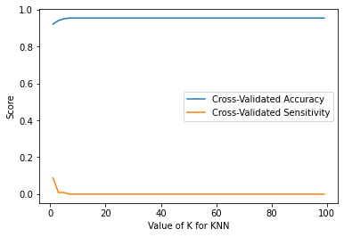

```python
# plot the value of K for KNN (x-axis) versus the cross-validated accuracy and sensitivity (y-axis)

plt.xlabel('Value of K for KNN')
plt.ylabel('Score')

plt.plot(k_scores['k'],k_scores['accuracy'])
plt.plot(k_scores['k'],k_scores['sensitivity'])
plt.legend(['Cross-Validated Accuracy', 'Cross-Validated Sensitivity'])
```

## Part 3: K means clustering (to categorise different types of employees)

We use K-means clustering to categorise different types of employees, in order to have a more nuanced picture of the behavioural patterns of employees. Same as our analysis above, each row represents an employee's behaviour during a particular period; there are multiple time periods being observed.

```python
scaler = StandardScaler()
clusterdata = all_data.iloc[:,[0,1,3,4,5,6,7,8,9,10,11]].set_index('employee')
clusterdata.iloc[:,:] = scaler.fit_transform(clusterdata.iloc[:,:].to_numpy())
kmeans = KMeans(n_clusters=5, random_state=42).fit(clusterdata)
all_data['cluster'] = kmeans.labels_
```

```python
print(all_data["cluster"].value_counts().sort_index())
cluster_characteristics = all_data.iloc[:,[0,1,3,4,5,6,7,8,9,10,11,13]].groupby("cluster").mean().round(2)
cluster_characteristics
```

```
0    1206
1     793
2     335
3       9
4     100
Name: cluster, dtype: int64
```

| cluster | length | dis_received | like_received | comment_count | dis_given | like_given | high_vote | low_vote | avg_vote | vote_count |
| --- | --- | --- | --- | --- | --- | --- | --- | --- | --- | --- |
| 0 | 0.05 | 0.09 | 0.30 | 0.02 | 0.10 | 0.39 | 1.10 | 0.30 | 2.66 | 1.41 |
| 1 | 0.07 | 1.86 | 5.31 | 0.33 | 2.40 | 5.60 | 11.47 | 0.39 | 3.38 | 11.86 |
| 2 | 0.10 | 1.64 | 3.39 | 0.21 | 1.75 | 5.13 | 0.87 | 10.80 | 1.56 | 11.67 |
| 3 | 0.00 | 86.67 | 150.33 | 10.89 | 18.56 | 35.67 | 3.22 | 11.44 | 1.60 | 14.67 |
| 4 | 14.74 | 0.45 | 2.97 | 0.13 | 1.44 | 3.05 | 4.89 | 2.34 | 2.71 | 7.23 |

After normalising the data, we categorised employee cases into 5 clusters, using k-means clustering. The most important cluster is Cluster 4, which singles out most of the absentee cases, since their average absent length (14.74 days) is significantly higher than other clusters, which are only absent for less than 0.1 days in a 2-week period on average.

It is notable that the non-absentee cases have a large variation of their level of engagement, happiness level, and in extension, level of motivation amongst themselves.

Cluster 0 has the largest number of cases, with a population of 1206. Its defining feature is its lack of engagement on the company’s online platforms. On average, they receive less than 1 dislike and 1 like, and give less than 1 dislike and 1 like in a 2-week period. These employees are the “silent majority” who rarely express themselves yet generally have good attendance.

Cluster 1 is also populous, with 793 cases. Their defining characteristic is that they represent the happiest employees in the company (with an average vote score of 3.38), and frequently express this sentiment with high votes (voting 11.47 times in 2 weeks).

Cluster 2 is the unhappy minority, with 335 cases. They have the lowest average vote score of 1.56.

Cluster 3 is a very small vocal minority, which only consists of a few employees who receive a lot of attention, interact very frequently, and are as unhappy as Cluster 2.

We can compare the absentee cluster with these 4 other clusters. The absentees’ level of engagement is relatively low: they receive less like and dislikes, give less likes and dislikes, and comment less frequently than all other Clusters except the "silent majority" cluster. However, on average, Cluster 4 votes around 5 times as frequently as the "silent majority". They cast significantly more low votes than Clusters 0 and 1 (both clusters collectively make up 82% of all cases). This echoes our observations in supervised learning models that absentees have low engagement with other employees, and regularly state their dissatisfaction through votes.